# Artigo Final - Análise de Dados - códigos

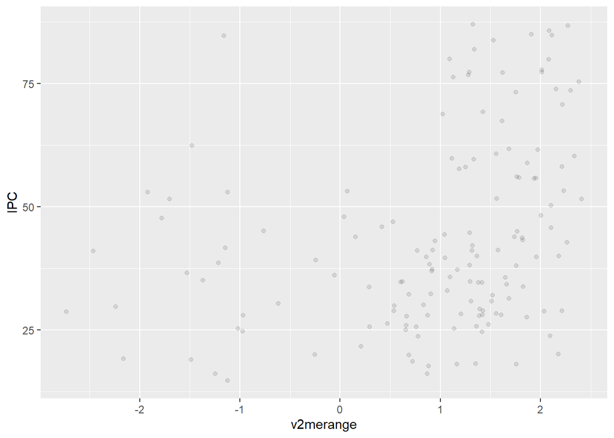

```r
ggplot(Banco_completo_renomeado, aes(v2merange, IPC)) +
  geom_jitter(alpha = 0.1)
```

##v2mecrit

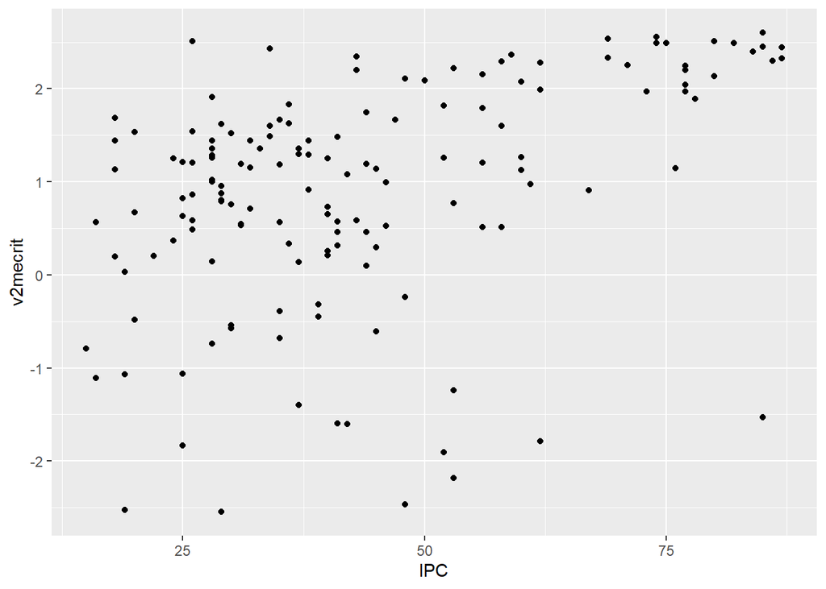

```r
ggplot(Banco_completo_renomeado,
       aes(IPC, v2mecrit)) +
  geom_point(alpha = 1)
```

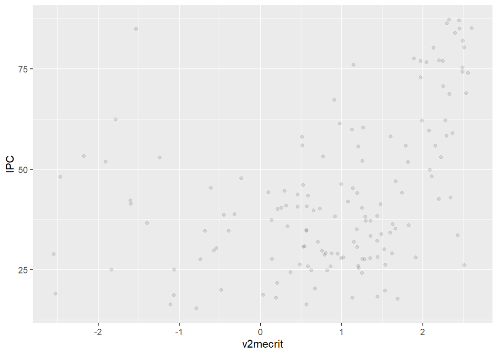

```r
ggplot(Banco_completo_renomeado, aes(v2mecrit, IPC)) +
  geom_jitter(alpha = 0.1)
```

#Testes de correlação

Para verificar a associação entre duas variáveis contínuas, usamos o teste r de pearson com a função cor.test(), de forma semelhante a função chisq.test():

cor.test(banco$variavel_x, banco$variavel_y)

O resultado apresenta ao seu final a correlação entre as variáveis. Logo antes, apresenta o intervalo de confiança da correlação. Se o valor 0 está neste intervalo, o resultado não possui significância estatística, como pode ser verificado pelo valor do p-valor.

##PIB

```r
cor.test(Banco_completo_renomeado$PIB, Banco_completo_renomeado$IPC)
```

```
##
##  Pearson's product-moment correlation
##
## data:  Banco_completo_renomeado$PIB and Banco_completo_renomeado$IPC
## t = 17.54, df = 147, p-value < 2.2e-16
## alternative hypothesis: true correlation is not equal to 0
## 95 percent confidence interval:
##  0.7626812 0.8685164
## sample estimates:
##       cor
## 0.8225985
```

##IDH

```r
cor.test(Banco_completo_renomeado$IDH, Banco_completo_renomeado$IPC)
```

```
##
##  Pearson's product-moment correlation
##
## data:  Banco_completo_renomeado$IDH and Banco_completo_renomeado$IPC
## t = -0.23042, df = 147, p-value = 0.8181
## alternative hypothesis: true correlation is not equal to 0
## 95 percent confidence interval:
##  -0.1792539  0.1422329
## sample estimates:
##         cor
## -0.01900161
```

##Qualidade da democracia

```r
cor.test(Banco_completo_renomeado$quali_democracia, Banco_completo_renomeado$IPC)
```

```
##
##  Pearson's product-moment correlation
##
## data:  Banco_completo_renomeado$quali_democracia and Banco_completo_renomeado$IPC
## t = 12.082, df = 147, p-value < 2.2e-16
## alternative hypothesis: true correlation is not equal to 0
## 95 percent confidence interval:
##  0.6148451 0.7783181
## sample estimates:
##       cor
## 0.7058589
```

##Variáveis de liberdade da mídia

##v2meharjrn

```r
cor.test(Banco_completo_renomeado$v2meharjrn, Banco_completo_renomeado$IPC)
```

```
##
##  Pearson's product-moment correlation
##
## data:  Banco_completo_renomeado$v2meharjrn and Banco_completo_renomeado$IPC
## t = 10.204, df = 147, p-value < 2.2e-16
## alternative hypothesis: true correlation is not equal to 0
## 95 percent confidence interval:
##  0.5389215 0.7292155
## sample estimates:
##       cor
## 0.6439203
```

##v2merange

```r
cor.test(Banco_completo_renomeado$v2merange, Banco_completo_renomeado$IPC)
```

```
##
##  Pearson's product-moment correlation
##
## data:  Banco_completo_renomeado$v2merange and Banco_completo_renomeado$IPC
## t = 3.8035, df = 147, p-value = 0.0002086
## alternative hypothesis: true correlation is not equal to 0
## 95 percent confidence interval:
##  0.1455314 0.4389969
## sample estimates:
##       cor
## 0.2993267
```

##v2mecrit

```r
cor.test(Banco_completo_renomeado$v2mecrit, Banco_completo_renomeado$IPC)
```

```
##
##  Pearson's product-moment correlation
##
## data:  Banco_completo_renomeado$v2mecrit and Banco_completo_renomeado$IPC
## t = 5.5161, df = 147, p-value = 1.521e-07
## alternative hypothesis: true correlation is not equal to 0
## 95 percent confidence interval:
##  0.2713907 0.5390249
## sample estimates:
##       cor
## 0.4141187
```

#Regressão Linear Multivariada

```r
regressao <- lm(IPC ~ PIB + IDH + v2meharjrn + v2merange + v2mecrit + quali_democracia, data = Banco_completo_renomeado)

summary(regressao)
```

```
##
## Call:
## lm(formula = IPC ~ PIB + IDH + v2meharjrn + v2merange + v2mecrit +
##     quali_democracia, data = Banco_completo_renomeado)
##
## Residuals:
##      Min       1Q   Median       3Q      Max
## -17.2571  -5.7089  -0.2247   4.7752  28.2301
##
## Coefficients:
##                    Estimate Std. Error t value Pr(>|t|)
## (Intercept)       1.976e+01  3.808e+00   5.187 7.21e-07 ***
## PIB               5.328e-04  4.327e-05  12.314  < 2e-16 ***
## IDH               3.403e-01  4.275e+00   0.080 0.936664
## v2meharjrn        4.286e+00  1.103e+00   3.885 0.000156 ***
## v2merange        -3.375e+00  1.237e+00  -2.729 0.007159 **
## v2mecrit         -2.748e+00  1.158e+00  -2.373 0.018985 *
## quali_democracia  3.133e-01  4.350e-02   7.202 3.18e-11 ***
## ---
## Signif. codes:  0 '***' 0.001 '**' 0.01 '*' 0.05 '.' 0.1 ' ' 1
##
## Residual standard error: 7.978 on 142 degrees of freedom
## Multiple R-squared:  0.8311, Adjusted R-squared:  0.824
## F-statistic: 116.5 on 6 and 142 DF,  p-value: < 2.2e-16
```